# Análisis de la Encuesta Nacional de Seguridad Pública Urbana (ENSU) del INEGI (2019-2026)

Autor/a

Lic. María Fernanda Rojas Barrera

Fecha de publicación

24 abril, 2026

# Introducción

La Encuesta Nacional de Seguridad Pública Urbana (ENSU) del Instituto Nacional de Estadística, Geografía e Informática (INEGI 2026), tiene como objetivo principal realizar estimaciones de la percepción de la población sobre la seguridad pública en ciudades de interés Nacional, los datos se publican trimestralmente y comenzó a realizarse a partir del tercer trimestre del 2013, y a lo largo del tiempo, se han tenido entre 70 (primer trimestres de 2019) a 91 ciudades de interés (primer trimestre del 2026).

A continuación, se muestra una tabla con cada una de las ciudades de cada ENSU que se analizaron para la creación de este documento:

| fila | ensu1t19 | ensu2t19 | ensu3t19 | ensu4t19 | ensu1t20 | ensu3t20 | ensu4t20 | ensu1t21 | ensu2t21 | ensu3t21 | ensu4t21 | ensu1t22 | ensu2t22 | ensu3t22 | ensu4t22 | ensu1t23 | ensu2t23 | ensu3t23 | ensu4t23 | ensu1t24 | ensu2t24 | ensu3t24 | ensu4t24 | ensu1t25 | ensu2t25 | ensu3t25 | ensu4t25 | ensu1t26 |
| --- | --- | --- | --- | --- | --- | --- | --- | --- | --- | --- | --- | --- | --- | --- | --- | --- | --- | --- | --- | --- | --- | --- | --- | --- | --- | --- | --- | --- |
| 1 | Acapulco, Gro. | Acapulco, Gro. | Acapulco, Gro. | Acapulco, Gro. | Acapulco, Gro. | Acapulco, Gro. | Acapulco, Gro. | Acapulco, Gro. | Acapulco, Gro. | Acapulco, Gro. | Acapulco, Gro. | Acapulco, Gro. | Acapulco, Gro. | Acapulco, Gro. | Acapulco, Gro. | Acapulco, Gro. | Acapulco, Gro. | Acapulco, Gro. | Aguascalientes, Ags. | Acapulco, Gro. | Acapulco, Gro. | Acapulco, Gro. | Acapulco, Gro. | Acapulco, Gro. | Acapulco, Gro. | Acapulco, Gro. | Acapulco, Gro. | Acapulco, Gro. |
| 2 | Aguascalientes, Ags. | Aguascalientes, Ags. | Aguascalientes, Ags. | Aguascalientes, Ags. | Aguascalientes, Ags. | Aguascalientes, Ags. | Aguascalientes, Ags. | Aguascalientes, Ags. | Aguascalientes, Ags. | Aguascalientes, Ags. | Aguascalientes, Ags. | Aguascalientes, Ags. | Aguascalientes, Ags. | Aguascalientes, Ags. | Aguascalientes, Ags. | Aguascalientes, Ags. | Aguascalientes, Ags. | Aguascalientes, Ags. | Álvaro Obregón, CDMX | Aguascalientes, Ags. | Aguascalientes, Ags. | Aguascalientes, Ags. | Aguascalientes, Ags. | Aguascalientes, Ags. | Aguascalientes, Ags. | Aguascalientes, Ags. | Aguascalientes, Ags. | Aguascalientes, Ags. |
| 3 | Apodaca, N.L. | Apodaca, N.L. | Álvaro Obregón, CDMX | Álvaro Obregón, CDMX | Álvaro Obregón, CDMX | Álvaro Obregón, CDMX | Álvaro Obregón, CDMX | Álvaro Obregón, CDMX | Álvaro Obregón, CDMX | Álvaro Obregón, CDMX | Álvaro Obregón, CDMX | Álvaro Obregón, CDMX | Álvaro Obregón, CDMX | Álvaro Obregón, CDMX | Álvaro Obregón, CDMX | Álvaro Obregón, CDMX | Álvaro Obregón, CDMX | Álvaro Obregón, CDMX | Apodaca, N.L. | Álvaro Obregón, CDMX | Álvaro Obregón, CDMX | Álvaro Obregón, CDMX | Álvaro Obregón, CDMX | Álvaro Obregón, CDMX | Álvaro Obregón, CDMX | Álvaro Obregón, CDMX | Álvaro Obregón, CDMX | Álvaro Obregón, CDMX |
| 4 | Cancún, Q. Roo | Atizapán, Mex. | Apodaca, N.L. | Apodaca, N.L. | Apodaca, N.L. | Apodaca, N.L. | Apodaca, N.L. | Apodaca, N.L. | Apodaca, N.L. | Apodaca, N.L. | Apodaca, N.L. | Apodaca, N.L. | Apodaca, N.L. | Apodaca, N.L. | Apodaca, N.L. | Apodaca, N.L. | Apodaca, N.L. | Apodaca, N.L. | Atizapán, Mex. | Apodaca, N.L. | Apodaca, N.L. | Apodaca, N.L. | Apodaca, N.L. | Apodaca, N.L. | Apodaca, N.L. | Apodaca, N.L. | Apodaca, N.L. | Apodaca, N.L. |
| 5 | CDMX Norte, CDMX | Cancún, Q. Roo | Atizapán, Mex. | Atizapán, Mex. | Atizapán, Mex. | Atizapán, Mex. | Atizapán, Mex. | Atizapán, Mex. | Atizapán, Mex. | Atizapán, Mex. | Atizapán, Mex. | Atizapán, Mex. | Atizapán, Mex. | Atizapán, Mex. | Atizapán, Mex. | Atizapán, Mex. | Atizapán, Mex. | Atizapán, Mex. | Azcapotzalco, CDMX | Atizapán, Mex. | Atizapán, Mex. | Atizapán, Mex. | Atizapán, Mex. | Atizapán, Mex. | Atizapán, Mex. | Atizapán, Mex. | Atizapán, Mex. | Atizapán, Mex. |
| 6 | CDMX Oriente, CDMX | CDMX Norte, CDMX | Azcapotzalco, CDMX | Azcapotzalco, CDMX | Azcapotzalco, CDMX | Azcapotzalco, CDMX | Azcapotzalco, CDMX | Azcapotzalco, CDMX | Azcapotzalco, CDMX | Azcapotzalco, CDMX | Azcapotzalco, CDMX | Azcapotzalco, CDMX | Azcapotzalco, CDMX | Azcapotzalco, CDMX | Azcapotzalco, CDMX | Azcapotzalco, CDMX | Azcapotzalco, CDMX | Azcapotzalco, CDMX | Benito Juárez, CDMX | Azcapotzalco, CDMX | Azcapotzalco, CDMX | Azcapotzalco, CDMX | Azcapotzalco, CDMX | Azcapotzalco, CDMX | Azcapotzalco, CDMX | Azcapotzalco, CDMX | Azcapotzalco, CDMX | Azcapotzalco, CDMX |
| 7 | CDMX Poniente, CDMX | CDMX Oriente, CDMX | Benito Juárez, CDMX | Benito Juárez, CDMX | Benito Juárez, CDMX | Benito Juárez, CDMX | Benito Juárez, CDMX | Benito Juárez, CDMX | Benito Juárez, CDMX | Benito Juárez, CDMX | Benito Juárez, CDMX | Benito Juárez, CDMX | Benito Juárez, CDMX | Benito Juárez, CDMX | Benito Juárez, CDMX | Benito Juárez, CDMX | Benito Juárez, CDMX | Benito Juárez, CDMX | Cancún, Q. Roo | Benito Juárez, CDMX | Benito Juárez, CDMX | Benito Juárez, CDMX | Benito Juárez, CDMX | Benito Juárez, CDMX | Benito Juárez, CDMX | Benito Juárez, CDMX | Benito Juárez, CDMX | Benito Juárez, CDMX |
| 8 | CDMX Sur, CDMX | CDMX Poniente, CDMX | Cancún, Q. Roo | Cancún, Q. Roo | Cancún, Q. Roo | Cancún, Q. Roo | Cancún, Q. Roo | Cancún, Q. Roo | Cancún, Q. Roo | Cancún, Q. Roo | Cancún, Q. Roo | Cancún, Q. Roo | Cancún, Q. Roo | Cancún, Q. Roo | Cancún, Q. Roo | Cancún, Q. Roo | Cancún, Q. Roo | Cancún, Q. Roo | Chetumal, Q. Roo | Cancún, Q. Roo | Cancún, Q. Roo | Cancún, Q. Roo | Cancún, Q. Roo | Cancún, Q. Roo | Cancún, Q. Roo | Cancún, Q. Roo | Cancún, Q. Roo | Cancún, Q. Roo |
| 9 | Chihuahua, Chih. | CDMX Sur, CDMX | Chihuahua, Chih. | Chihuahua, Chih. | Chihuahua, Chih. | Chihuahua, Chih. | Chihuahua, Chih. | Chihuahua, Chih. | Chihuahua, Chih. | Chetumal, Q. Roo | Chetumal, Q. Roo | Chetumal, Q. Roo | Chetumal, Q. Roo | Chetumal, Q. Roo | Chetumal, Q. Roo | Chetumal, Q. Roo | Chetumal, Q. Roo | Chetumal, Q. Roo | Chihuahua, Chih. | Chetumal, Q. Roo | Chetumal, Q. Roo | Chetumal, Q. Roo | Chetumal, Q. Roo | Chetumal, Q. Roo | Chetumal, Q. Roo | Chetumal, Q. Roo | Chetumal, Q. Roo | Chetumal, Q. Roo |
| 10 | Chilpancingo de los Bravo, Gro. | Chihuahua, Chih. | Chilpancingo de los Bravo, Gro. | Chilpancingo de los Bravo, Gro. | Chilpancingo de los Bravo, Gro. | Chilpancingo de los Bravo, Gro. | Chilpancingo de los Bravo, Gro. | Chilpancingo de los Bravo, Gro. | Chilpancingo de los Bravo, Gro. | Chihuahua, Chih. | Chihuahua, Chih. | Chihuahua, Chih. | Chihuahua, Chih. | Chihuahua, Chih. | Chihuahua, Chih. | Chihuahua, Chih. | Chihuahua, Chih. | Chihuahua, Chih. | Chilpancingo de los Bravo, Gro. | Chihuahua, Chih. | Chihuahua, Chih. | Chihuahua, Chih. | Chihuahua, Chih. | Chihuahua, Chih. | Chihuahua, Chih. | Chihuahua, Chih. | Chihuahua, Chih. | Chihuahua, Chih. |

[output cut: 81 more lines]

## Metodología

Se descargaron las bases de datos, del 2019 al 2026 por trimestre, de la Encuesta Nacional de Seguridad Pública Urbana (ENSU) del Instituto Nacional de Estadística, Geografía e Informática (INEGI), trabajando especialmente con los conjutos de datos del cuestionario principal de la ENSU (terminación CB), que son las preguntas enfocadas a obtener información sobre la percepción de la población de 18 años y más, acerca de la situación de seguridad pública en el ámbito urbano.

Se descargaron las bases de datos del cuestionario sociodemográfico para el 2019 y el primer trimestre del 2020, ya que en dichos periodos, esos cuestionarios contienen los valores de sexo y edad.

También, se descargó el catálogo de las Claves Geoestadísticas (CVEGEO) de todos los municipios del país y el Catálogo de Ciudades (estandarizado con lo reportado en el segundo trimestre del 2025), con el fin de homogenizar los nombres de las ENTIDADES, MUNICIPIOS y CIUDADES de las bases de datos, ya que no es lo mismo “Cuajimalpa” que “Cuajimalpa de Morelos”, o bien, “México” que “Estado de México”, y si vamos a comparar diversos años, lo importante es estandarizar esos datos. Además, se agregaron siglas de cada ciudad que usa el INEGI para su representación en algunos documentos como los resultados de la ENSU del cuarto trimestre del 2024.

Después al catálogo de ciudades del segundo trimestre del 2025, se agregaron todas las ciudades que han sido evaluadas desde el 2019, que por diferentes motivos como la regionalización de la CDMX o el trabajo por Convenios entre el INEGI con otros municipios, el catálogo ha ido creciendo con el tiempo.

Además, en diversas secciones del presente reporte, se hace mención que los resultados pueden ser corroborados en los tabulados básicos y complementarios de la ENSU, especificamente en los archivos con la siguiente nomenclatura: `1.Bas_percepcion_MES_ANIO_est` y `1.Com_percepcion_MES_ANIO_est`. Se menciona que los tabulados complementarios comenzaron a existir desde 2024, por lo que para obtener y replicar los resultados del presente hacia el pasado, se elaboraron diversas funciones dentro de las cuales se pudieron obtener los datos esperados para los tabulados complementarios de los años faltantes.

Todos los documentos empleados pueden consultarse en el [repositorio](https://github.com/cartodev09014/ENSU_datos).

También, se hicieron correcciones breves (sin alterar los documentos originales), a los archivos CS y CB del INEGI, en el sentido de que algunos presentaban inconsistencias como:

- Retorno de carro (`\r`).
- Uso de valores literalmente escritos como NA en columnas de tipo integer.
- Separación de variables BP1_6_X para los trimestres impares y pares.
- Falta de homogenización de los nombres de las ciudades evaluadas.

Así mismo, se realizaron actividades como:

- Renombre de variables BP2_4_X para que todos los df sean iguales.
- Unión de columnas de SEXO y EDAD entre los data frames CS y CB, desde el año 2020 hacia el pasado.
- Unión de columnas FAC_VIV entre los data frames CS y CB, desde el tercer trimestre del 2022 hacia el pasado.
- Se agregaron columnas auxiliares como NOMGRAFICA (nombre de la ciudad de interés conforme al catálogo creado), NOM_ABR (nombre abreviado de la ciudad), ENT_ABR (abreviatura de la entidad federativa de la ciudad).
- Se agregaron las columnas del año, periodo y nombre del df.

**Nota: Para el 1er trimestre de 2026, se agrega una nueva pregunta que comprende el uso de la línea de atención telefónica 911, que se incluyo en la Sección 4. Confianza en los niveles de gobierno.**

## Secciones contenidas en la ENSU

Finalmente, tras una revisión exhaustiva de todas las Secciones evaluadas en cada Encuesta Nacional, se creó un cronograma respecto a la aparición de cada sección, este mismo orden será el que se presentará en cada capítulo del presente reporte, además de incluir primero la forma en la que se realizó el diseño muestral **para replicar los resultados del INEGI**. Las secciones son:

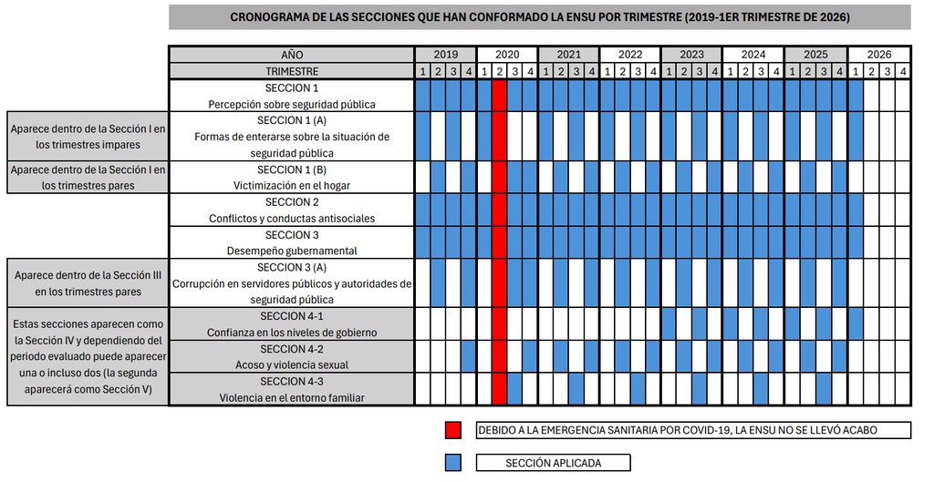

- Diseño muestral, ubicado en:

1 Diseño muestral

- Percepción sobre seguridad pública, que abarca:

2 Percepción de inseguridad en áreas urbanas de interés 3 Percepción de inseguridad por espacio físico específico 4 Expectativa social sobre seguridad pública 5 Atestiguación de tipos de conductas delictivas o antisociales 6 Cambio de hábitos por temor al delito

- Formas de enterarse sobre la situación de seguridad pública, ubicado en:

7 Formas de enterarse sobre la situación de seguridad pública

- Victimización en el hogar, ubicado en:

8 Victimización en el hogar

- Percepción sobre el desempeño de autoridades, ubicado en:

9 Percepción sobre el desempeño de autoridades (identificación y desempeño) 10 Percepción sobre el desempeño de autoridades (identificación y confianza)

- Conflictos y conductas antisociales, que abarca:

11 Conflictos o enfrentamientos 12 Conflictos directos (personas con quienes se tuvieron los conflictos) 13 Consecuencias de los conflictos

- Desempeño gubernamental, que abarca:

14 Problemáticas urbanas 15 Efectividad del Gobierno para atender las problemáticas 16 Actividades o programas para prevenir la violencia y/o la delincuencia

- Corrupción en servidores públicos y autoridades de seguridad pública, ubicado en:

17 Corrupción en servidores públicos y autoridades de seguridad pública

- Confianza en los niveles de gobierno, ubicado en:

18 Confianza en los niveles de Gobierno 19 Uso de la línea telefónica de emergencia 911

- Acoso y violencia sexual, ubicado en:

19 Acoso y violencia sexual

- Violencia en el entorno familiar, ubicado en:

20 Violencia en el entorno familiar

INEGI. 2026. «Encuesta Nacional de Seguridad Pública Urbana (ENSU), primer trimestre de 2019 a primer trimestre de 2026». *ENSU*. https://www.inegi.org.mx/programas/ensu/.